# Plotting spatial data with ggplot

You can create beautiful maps using ggplot. The focus of this page is to offer a minimal example of how you can quickly plot a spatial dataset. This will be useful if you have loaded some data and you want to quickly confirm that the file contains what you expected it to.

# Required packages

This skills page uses the following three packages:

```r
library(tidyverse)
library(sf)
library(here)
```

# Load data

I’ll start by reading in some data You can read more about that [here](https://c-voulgaris.github.io/VIS-2128-F22/a1-files/skill-open-file.html).

```r
SLO_streets <- st_read(here("a1-files",
                            "SLO-streets.geojson"))
bus_stops <- st_read(here("a1-files",
                          "bus-stops.csv"),
                     options=c("X_POSSIBLE_NAMES=stop_lon",
                               "Y_POSSIBLE_NAMES=stop_lat")) %>%
  st_set_crs("WGS84")
```

```
## options:        X_POSSIBLE_NAMES=stop_lon Y_POSSIBLE_NAMES=stop_lat
```

# Plot data

You can use the `ggplot()` for a wide variety of data visualizations, including scatter plots, bar charts, histograms, and (what we’ll use it for here) maps.

The first line in the code chunk below sets up the plot and specifies the dataset the plot will represent. `geom_sf()` indicates that we want to plot the spatial data as a map.

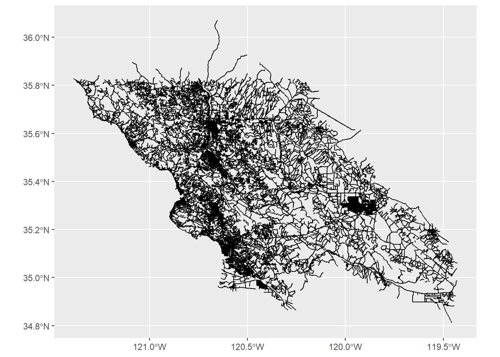

```r
ggplot(SLO_streets) +
  geom_sf()
```

If you want to plot another layer on top of that (perhaps just to confirm that it has about the same spatial extent), you can call `geom_sf()` again, but this time you’ll need to specify the data layer within that function. You might also want to change the color of the second layer to make it easier to see.

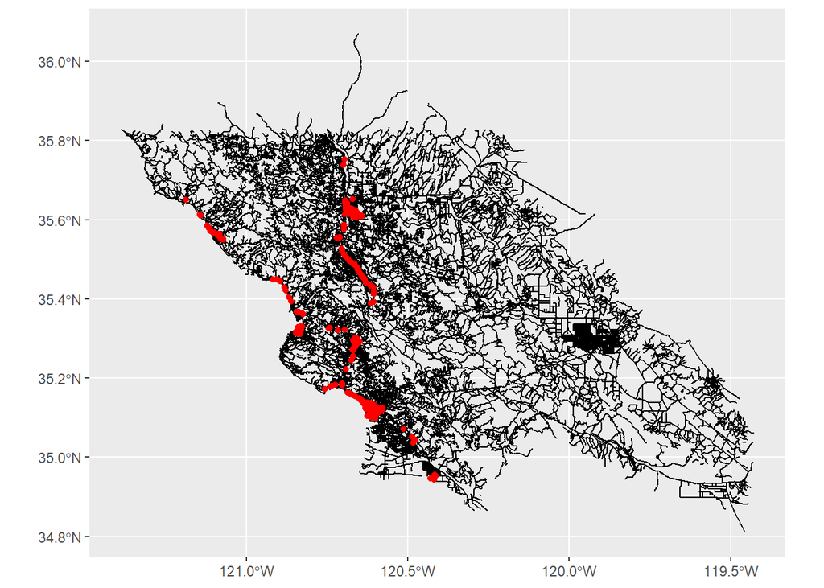

```r
ggplot(SLO_streets) +
  geom_sf() +
  geom_sf(data = bus_stops,
          color = "red")
```